# Comparing several people

Comparing several people Roberto Olayo 3/14/2021

So let’s see what we got

I use these libraries for the following analysis. Nothing like the tidyverse, right?

```r
library(tidyverse)
library(factoextra)
```

Here is the data table that I gathered. It contains a lot of info, including our usernames, which is why I am not showing it here. Suffice to say that there is a lot of metadata about the song, as well as an analysis of the songs’ characteristics

```r
complete_info <- read_tsv('../user_song_information.tsv')
complete_info <- complete_info %>%
  mutate(User_Initial=sapply(complete_info$User, function(x){substr(x, 1, 1)}))
```

## Song Features

An good initial way to compare the distribution of values is to look at violin plots. These plots are wider where there are more values and narrower where there are less values. Within each violin plot, there is a smaller, regular boxplot.

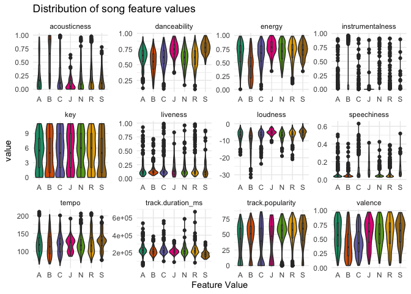

```r
numerical_info <- complete_info %>%
                  select(track.duration_ms, track.popularity, danceability,
                         energy, key, loudness, speechiness, acousticness,
                         instrumentalness, liveness, valence, tempo, track.id,
                         User_Initial)

numerical_info <- numerical_info %>%
                  gather(track.duration_ms, track.popularity, danceability,
                         energy, key, loudness, speechiness, acousticness,
                         instrumentalness, liveness, valence, tempo,
                         key=feature, value=value)

ggplot(numerical_info, aes(x=User_Initial, y=value, fill=User_Initial)) +
  geom_violin() +
  geom_boxplot(width=0.1, fill="white")  +
  scale_fill_brewer(palette="Dark2") +
  facet_wrap(~feature, scales='free') +
  theme_minimal() +
  theme(legend.position = 'none') +
  labs(title = "Distribution of song feature values",
       x="Feature Value")
```

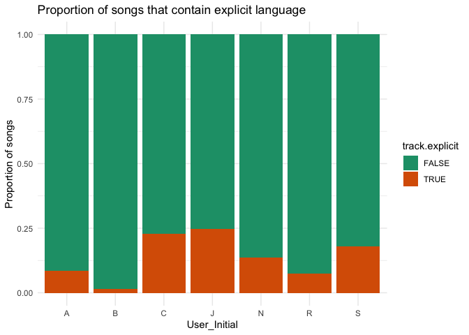

```r
explicit_info <- complete_info %>%
  group_by(User_Initial) %>%
  count(track.explicit)

exp_fig <- ggplot(explicit_info, aes(x=User_Initial, y=n, fill=track.explicit)) +
  geom_bar(position = 'fill', stat='identity') +
  scale_fill_brewer(palette = 'Dark2') +
  theme_minimal() +
  labs(y='Proportion of songs',
       title="Proportion of songs that contain explicit language")
exp_fig
```

## Favourite time period

How about what time period we listen to? We can compare the release dates of the albums that contain the songs we listen to. Maybe one of us likes oldies more.

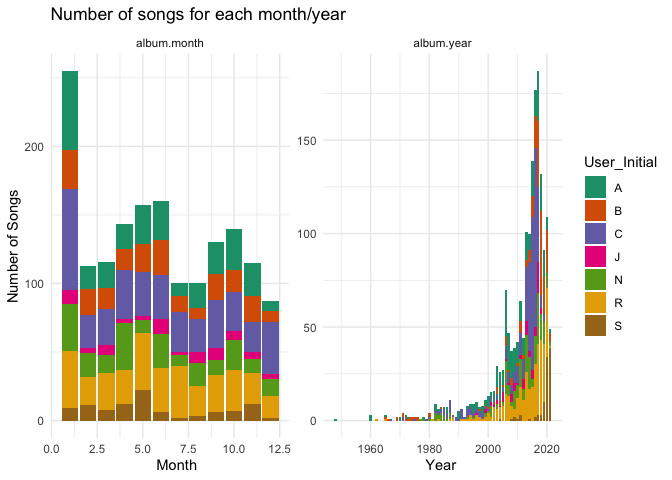

```r
time_info <- complete_info %>%
  separate(track.album.release_date, c('album.year', 'album.month', 'album_day'), '-') %>%
  mutate(album.year = as.integer(album.year),
         album.month = as.integer(album.month)) %>%
  select(track.id, User_Initial, album.year, album.month) %>%
  gather(album.year, album.month, key=timemeasure, value=value)

date_info <- time_info %>%
  group_by(User_Initial, timemeasure) %>%
  count(value) %>%
  rename(n_songs = n,
         time_measure = value)


bar <- ggplot(date_info, aes(x=time_measure, y=n_songs, fill=User_Initial)) +
  geom_bar(stat="identity") +
  scale_fill_brewer(palette="Dark2") +
  facet_wrap(~timemeasure, scales = 'free') +
  theme_minimal() +
  labs(x="Month                                                        Year",
       y='Number of Songs', title = "Number of songs for each month/year")

bar
```

# Some Multidimensional Statistics

## Are our songs distinguishable from eachother?

So, just how different are our songs? One way to asnwer this question is to perform an analysis known as Principal Component Analysis (PCA). Basically, we can collapse the variables that describe our songs (danceability, valence, speechiness, etc) into two *components* such that the variance between our songs is maximized. This will let us know if the feature values of our songs are different or not.

I think we can limit the analysis to the characteristics of the songs themselves, leaving out external stuff such as popularity.

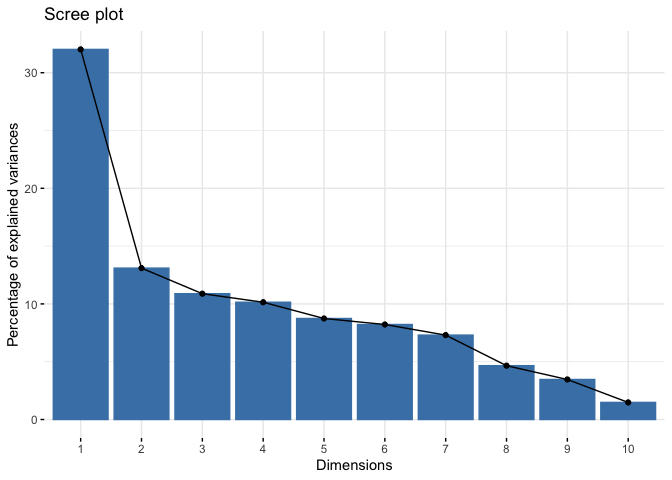

```r
# Getting shared songs
shared_songs <- complete_info %>% count(track.id) %>% filter(n > 1)
complete_info <- complete_info %>%
  mutate(User = replace(User_Initial, track.id %in% shared_songs$track.id, "Shared")) %>%
  distinct(track.id, .keep_all=TRUE)


song_numerical <- complete_info %>%
  select(track.id, danceability, energy, loudness, speechiness, acousticness,
         instrumentalness, liveness, valence, tempo, duration_ms,) %>%
  distinct(track.id, .keep_all=TRUE) %>%
  column_to_rownames(var="track.id")

res.pca <- prcomp(song_numerical, scale = TRUE)
scree <- fviz_eig(res.pca)
scree
```

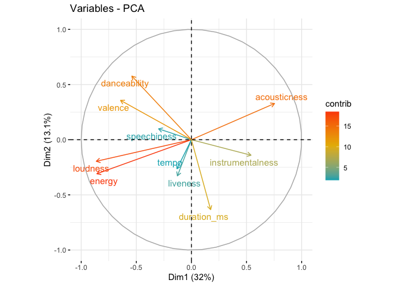

```r
fviz_pca_var(res.pca,
             col.var = "contrib", # Color by contributions to the PC
             gradient.cols = c("#00AFBB", "#E7B800", "#FC4E07"),
             repel = TRUE     # Avoid text overlapping
             )
```

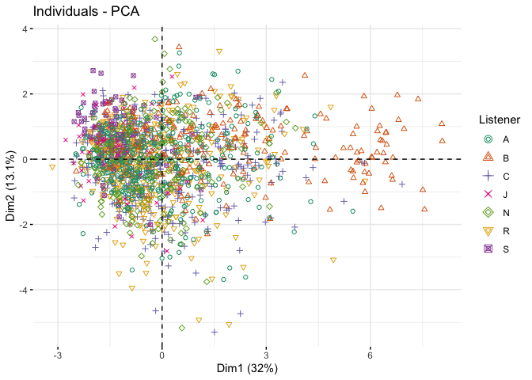

```r
listener <- as.factor(complete_info$User_Initial)

fviz_pca_ind(res.pca,
             col.ind = listener, # color by groups
             palette = c("#1b9e77", "#d95f02","#7570b3", "#e7298a", "#66a61e", "#e6ab02", "#984ea3"),
             legend.title = "Listener",
             repel = TRUE,
             geom = 'point'
             )
```

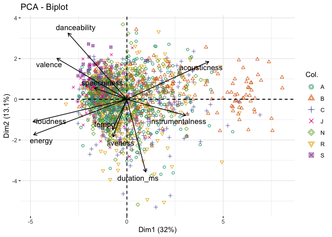

```r
fviz_pca_biplot(res.pca, repel = TRUE,
                col.var = "black", # Variables color
                col.ind = listener,  # Individuals color
                palette = c("#1b9e77", "#d95f02","#7570b3", "#e7298a", "#66a61e", "#e6ab02", "#984ea3"),
                geom = 'point')
```

# K-means clustering

We can get an idea of how many K’s to cluster our songs into, with the following plot. Basically, it lets us know how different the songs within a certain cluster are. As we increase the number of clusters, the sum of squares decreases, since the songs will become more similar.

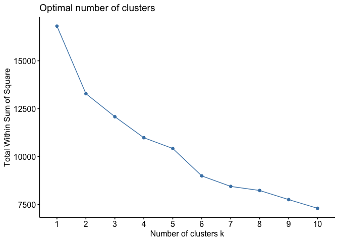

```r
song_numerical.scaled <- scale(song_numerical)

fviz_nbclust(song_numerical.scaled, kmeans, method = "wss")
```

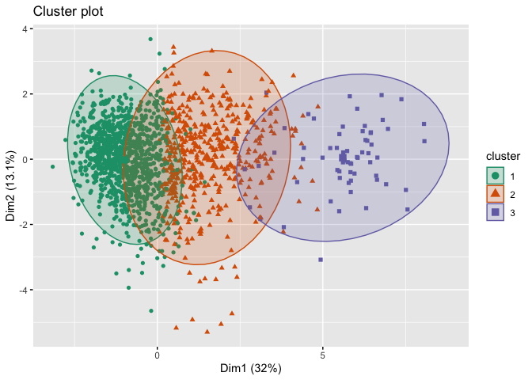

```r
set.seed(42)
k2 <- kmeans(song_numerical.scaled, 3, nstart = 25)

fviz_cluster(k2, data = song_numerical.scaled,
             geom='point', ellipse.type = "norm",
             palette='Dark2')
```

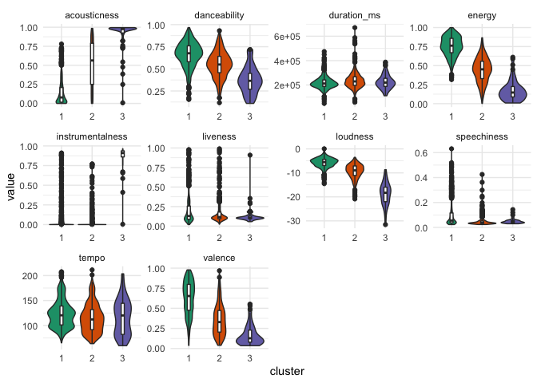

```r
song_clusters2 <-song_numerical %>%
  mutate(cluster=as.factor(k2$cluster),
         User=complete_info$User) %>%
  rownames_to_column(var="track.id") %>%
  gather(danceability, energy, loudness, speechiness, acousticness, instrumentalness,
         liveness, valence, tempo, duration_ms,
         key=feature, value=value)

vp <- ggplot(song_clusters2, aes(x=cluster, y=value, fill=cluster)) +
  geom_violin() +
  geom_boxplot(width=0.1, fill="white")  +
  scale_fill_brewer(palette="Dark2") +
  facet_wrap(~feature, scales='free') +
  theme_minimal() +
  theme(legend.position = 'none')

vp
```

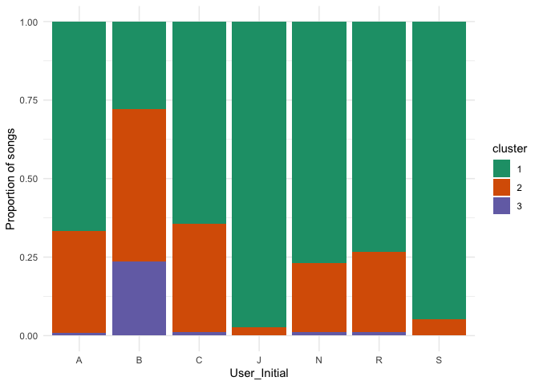

```r
cluster2_user <- complete_info %>%
  mutate(cluster=as.factor(k2$cluster)) %>%
  group_by(User_Initial) %>%
  count(cluster) %>%
  subset(User_Initial != "Shared")


exp_fig <- ggplot(cluster2_user, aes(x=User_Initial, y=n, fill=cluster)) +
  geom_bar(position = 'fill', stat='identity') +
  scale_fill_brewer(palette = 'Dark2') +
  theme_minimal() +
  labs(y='Proportion of songs')
exp_fig
```